# Determining Predictors in Survival for Breast Cancer Patients Using LASSO Regression

Stephanie Hopkins & Aminata Gado Oumarou (Advisor: Dr. Cohen)

2026-04-22

## Introduction: What is LASSO Regression?

- LASSO - Least Absolute Shrinkage and Selection Operator
- Introduced by Robert Tibshirani in 1996
- Method for variable selection and regularization to improve prediction accuracy and interpretability (Ranstam and Cook 2018)
  - Shrinks less important variables to zero
  - Helps prevent overfitting
- Widely used - medicine, biology, computational social sciences, social media, the stock market, economics, political science, robotics, climatology, and pharmacology (Emmert-Streib and Dehmer 2019)

## Introduction: Breast Cancer

- In 2019, over 3.8 million people in the U.S. were living with breast cancer. In 2025, 2.04 million new cancer cases were diagnosed. It is the most commonly diagnosed cancer among women and the second most common cancer globally (Usman, SIS, and Alhaji 2021) (National Cancer Institute 2025)
- There are many causes, including hereditary factors, age, obesity, alcohol or smoking, and other factors
- Prognosis and survival are commonly grouped into three categories: (1) demographic and genetic characteristics, (2) clinicopathological factors, and (3) treatment-related variables such as drug therapy, radiotherapy, and chemotherapy (Teng et al. 2022)

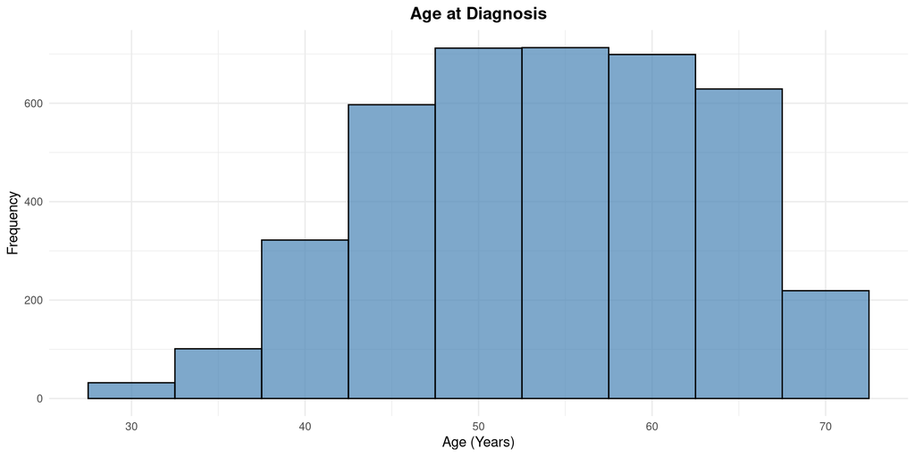

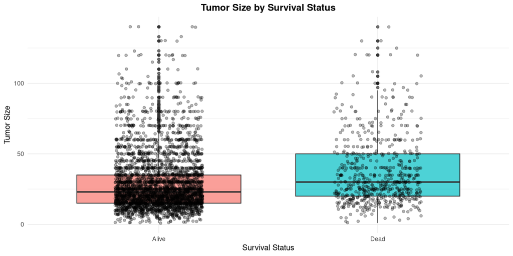

## Methods

- LASSO Regression
- LASSO-Cox Regression
- LASSO is defined as (Emmert-Streib and Dehmer 2019):

$$\hat{\beta} = arg \space \min \left\{\frac{1}{2n} \sum_{i=1}^{n} (y_i - \sum_{j} \beta_j x_{ij})^2 + \lambda||\beta||_1\right\}$$

- $y_{i}$ represents the observed outcome
- $x_{ij}$ denotes predictor values
- β is the vector of regression coefficients
- λ is a tuning parameter
- L1 penalty encourages sparsity by shrinking weaker coefficients exactly to zero
- For the LASSO-Cox model, coefficients are instead estimated by maximizing the penalized Cox partial likelihood:

$$\hat{\beta}_{\text{LASSO-Cox}} = \arg_{\beta}\max\left \{PL(\beta) - \lambda \sum_{j=1}^{p}|\beta_j| \right\}$$

- PL(β) denotes the Cox partial likelihood function
- λ is a positive tuning parameter that controls the amount of shrinkage
- L1 penalty shrinks some regression coefficients to zero while estimating hazard ratios for the remaining predictors

**Assumptions:**

- Hazard ratios between individuals remain constant over time (proportional hazards assumption)
- Survival times of different patients are independent from one another
- Censoring is assumed to be non-informative, meaning that the reason for censoring is unrelated to the probability of the event

## Analysis and Results

- Determine predictors in survival for breast cancer patients using Surveillance, Epidemiology, and End Results (SEER) dataset
- Composed of 4,024 patients with ductal and lobular breast carcinoma between 2006 and 2019
- Excludes patients with unknown tumor size, examined regional lymph nodes (LNs), regional positive LNs, and patients whose survival months were less than 1 month

Table 1. Characteristics of the variables included in the study.

| Category | Variables |
| --- | --- |
| Demographics | Age at diagnosis, race, marital status (married, single, widowed, divorced, separated) |
| Tumor Characteristics | T stage (T1–T4), N stage (N1–N3), 6th AJCC stage (IIA–IIIC), tumor grade (I–IV), A stage (regional/distant), tumor size |
| Hormone Receptors | Estrogen status, progesterone status (positive/negative) |
| Lymph Nodes | Nodes examined, nodes positive |
| Outcome | Survival months, vital status (alive/dead) |

## Kaplan-Meier Estimate of Survival

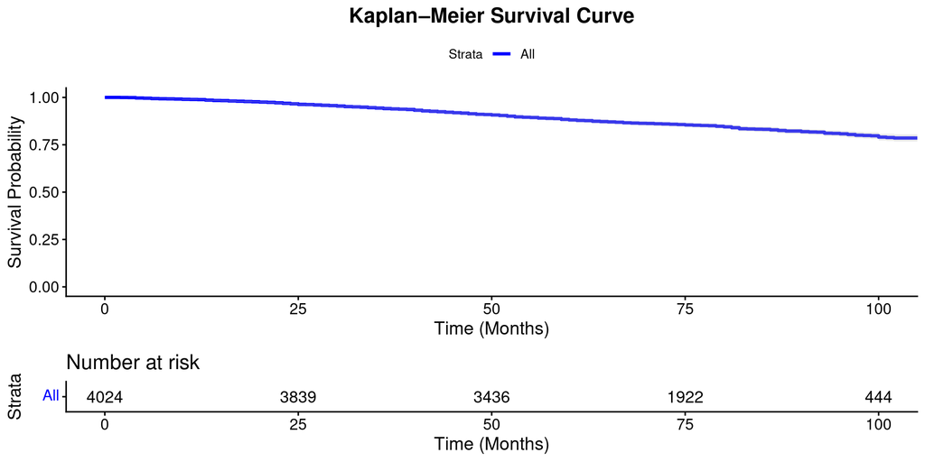

- Survival curve indicates a gradual decline in survival probability over time, beginning at 100% at baseline and decreasing steadily to approximately 78% by 100 months
- Relatively high survival across the study population with a slow and consistent reduction in survival probability over time

## Kaplan-Meier Survival by 6th Stage

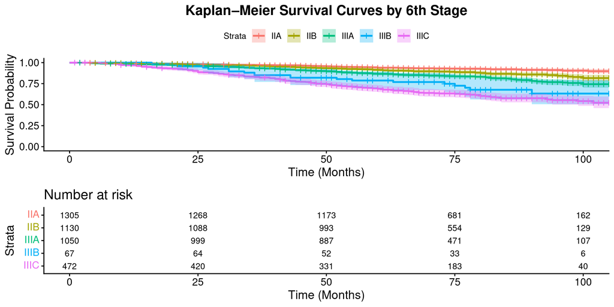

- Patients diagnosed at earlier stages (IIA, IIB) generally show higher survival probabilities throughout the follow-up period
- Patients diagnosed at later stages (IIIA, IIIB, IIIC) experience a faster decline in survival probability over time
- Suggests patients diagnosed with more advanced stages tend to have lower survival probabilities compared to those diagnosed at earlier stages

## Modeling and Results

- LASSO-penalized Cox proportional hazards model was used to identify key predictor of breast cancer survival
- Categorical predictors were converted into indicator (dummy) variables
- Continuous variables were standardized automatically within the glmnet framework to ensure that no single variable dominated the L1 penalty applied by LASSO
- Observations with missing values were removed to maintain consistency in the analysis
- Survival object was created using the survival time and event indicator
- Predictor variables were converted into a model matrix
- Fit model using glmnet which estimated regression coefficients while applying regularization to perform variable selection

## Coefficient Path Plot

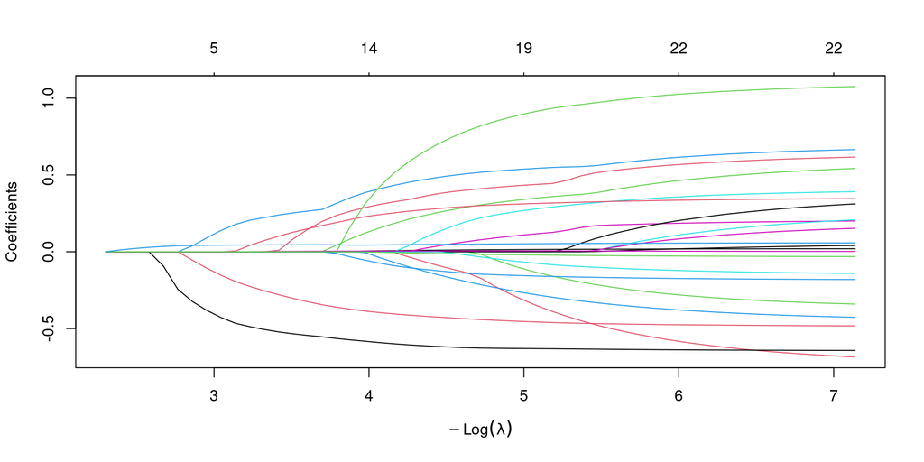

- Demonstrates how predictor effects evolve as the penalty parameter (λ) decreases
- The x-axis, -log(λ), represents the strength of the penalty
- The y-axis displays the estimated coefficients, indicating the magnitude and direction of each predictor’s effects
- The numbers along the top of the model represent the number of non-zero coefficients at each value of λ

## Optimal Lambda Value

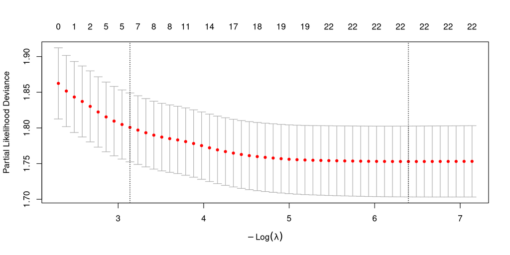

- Displays the mean cross-validation error and associated confidence intervals for each λ
- Error decreases as more variables are included, then stabilizes
- Optimal λ is selected using cross-validation
- Indicates that a simpler model performs similarly to a more complex one

## LASSO-Cox Model Results

Selected Predictors from the LASSO-Cox Model

|  | Variable | Coefficient | Interpretation |
| --- | --- | --- | --- |
| 1 | Age | 0.019 | Increased hazard (worse survival) |
| 2 | RaceOther (American Indian/AK Native, Asian/Pacific Islander) | -0.632 | Decreased hazard (better survival) |
| 3 | RaceWhite | -0.310 | Decreased hazard (better survival) |
| 4 | Marital.StatusMarried (including common law) | -0.177 | Decreased hazard (better survival) |
| 5 | Marital.StatusSeparated | 0.374 | Increased hazard (worse survival) |
| 8 | T.StageT2 | 0.192 | Increased hazard (worse survival) |
| 9 | T.StageT3 | 0.254 | Increased hazard (worse survival) |
| 10 | T.StageT4 | 0.591 | Increased hazard (worse survival) |
| 11 | N.StageN2 | 0.500 | Increased hazard (worse survival) |
| 12 | N.StageN3 | 0.639 | Increased hazard (worse survival) |
| 13 | X6th.StageIIB | 0.156 | Increased hazard (worse survival) |
| 15 | X6th.StageIIIB | 0.116 | Increased hazard (worse survival) |
| 16 | X6th.StageIIIC | 0.028 | Increased hazard (worse survival) |
| 17 | GradePoorly differentiated; Grade III | 0.340 | Increased hazard (worse survival) |
| 18 | GradeUndifferentiated; anaplastic; Grade IV | 1.049 | Increased hazard (worse survival) |
| 19 | GradeWell differentiated; Grade I | -0.401 | Decreased hazard (better survival) |
| 20 | A.StageRegional | -0.131 | Decreased hazard (better survival) |
| 21 | Tumor.Size | 0.003 | Increased hazard (worse survival) |
| 22 | Estrogen.StatusPositive | -0.640 | Decreased hazard (better survival) |
| 23 | Progesterone.StatusPositive | -0.479 | Decreased hazard (better survival) |
| 24 | Regional.Node.Examined | -0.030 | Decreased hazard (better survival) |
| 25 | Reginol.Node.Positive | 0.057 | Increased hazard (worse survival) |

## Conclusion

- Identified 22 predictors with non-zero coefficients at the optimal penalty parameter
- Positive coefficients linked to an increased hazard, or worse survival
- Negative coefficients linked to a decreased hazard, or better survival
- Five most influential variables selected: Grade IV (Undifferentiated; Anaplastic) ($\beta = 1.049$), Other races (American Indian/AK Native, Asian/Pacific Islander) ($\beta = -0.632$), N stage N3 ($\beta = 0.639$), estrogen receptor positive status ($\beta = -0.640$), and T stage T4 ($\beta = 0.591$)
- Patients with Grade IV tumors, N stage N3, and T stage T4 exhibited worse survival outcomes
- Other races and those with positive estrogen receptor status showed improved survival
- Both demographic and biological factors play a meaningful role in prognosis
- Different penalty parameter (λ) could lead to a slightly different set of predictors

## References

Emmert-Streib, Frank, and Matthias Dehmer. 2019. “High-Dimensional LASSO-Based Computational Regression Models: Regularization, Shrinkage, and Selection.” *Machine Learning and Knowledge Extraction* 1 (1): 359–83.

National Cancer Institute. 2025. “Cancer Statistics.” https://www.cancer.gov/about-cancer/understanding/statistics.

Ranstam, Jonas, and Jonathan A Cook. 2018. “LASSO Regression.” *Journal of British Surgery* 105 (10): 1348–48.

Teng, Jing, Honglei Zhang, Wuyi Liu, Xiao-Ou Shu, and Fei Ye. 2022. “A Dynamic Bayesian Model for Breast Cancer Survival Prediction.” *IEEE Journal of Biomedical and Health Informatics* 26 (11): 5716–27.

Usman, M, Doguwa SIS, and BB Alhaji. 2021. “COMPARING THE PREDICTION ACCURACY OF RIDGE, LASSO AND ELASTIC NET REGRESSION MODELS WITH LINEAR REGRESSION USING BREAST CANCER DATA.” *Bayero Journal of Pure & Applied Sciences* 14 (2).